# Statistical Analysis of the Fruit Survey

### 1.3. Graphical representation

#### 1.3.1. Boxplot of Fruits

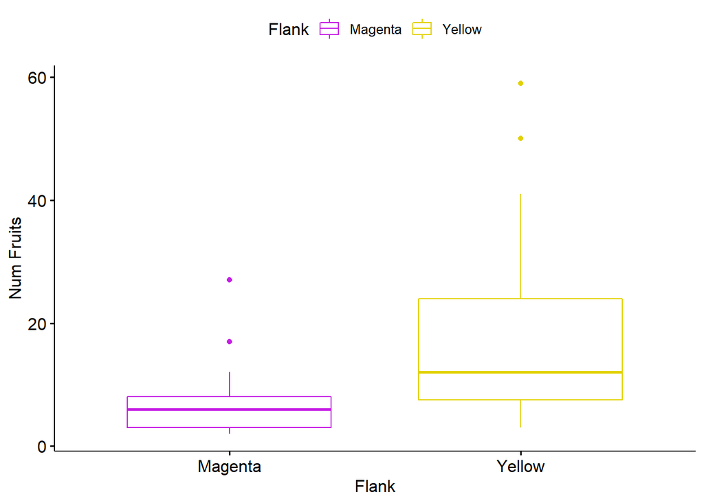

```r
ggboxplot(envelopes_df, x = "Flank", y = "Fruits",
          color = "Flank", palette = c("#C61DE5", "#E2D100"),
          ylab = "Num Fruits", xlab = "Flank")
```

#### 1.3.2. Boxplot of Damage

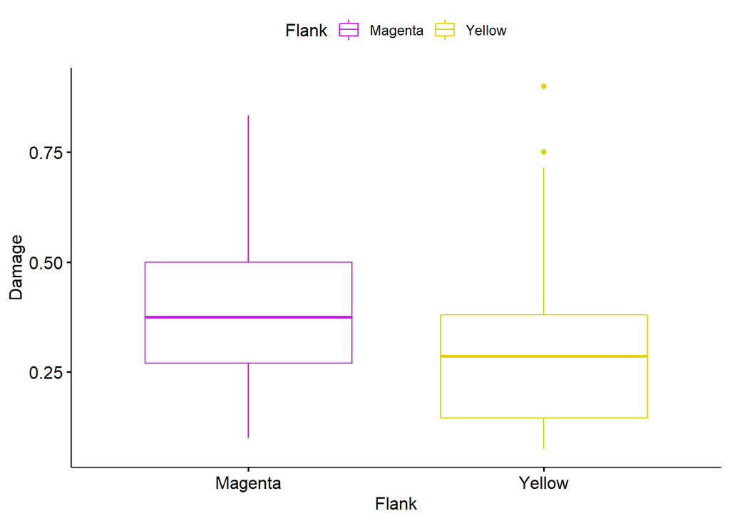

```r
ggboxplot(envelopes_df, x = "Flank", y = "Damage",
          color = "Flank", palette = c("#C61DE5", "#E2D100"),
          ylab = "Damage", xlab = "Flank")
```

#### 1.3.3. Correlation Damage vs number of Fruits

##### 1.3.3.1. Linear

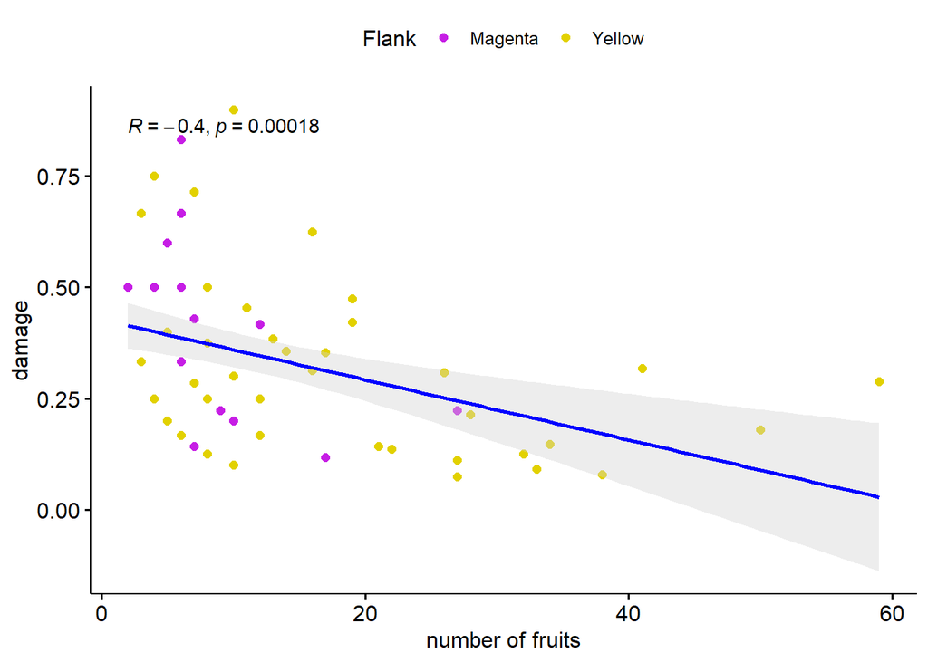

```r
ggscatter(envelopes_df, x = "Fruits", y = "Damage", color = "Flank", palette = c("#C61DE5", "#E2D100"),
          add = "reg.line", add.params = list(color = "blue", fill = "lightgray"), conf.int = TRUE,
          cor.coef = TRUE, cor.method = "pearson",
          xlab = "number of fruits", ylab = "damage")
```

##### 1.3.3.2. Non linear

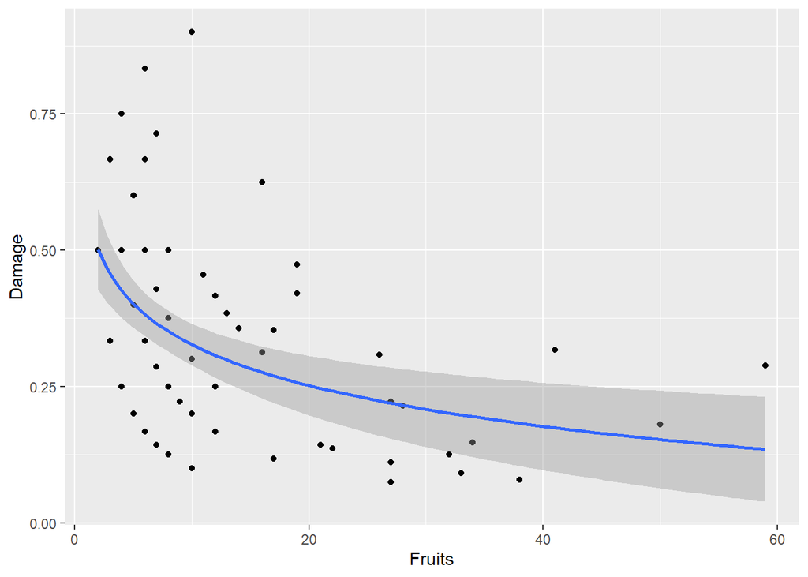

```r
ggplot(envelopes_df, aes(Fruits, Damage) ) +
  geom_point() +
  stat_smooth(method = lm, formula = y ~ log(x))
```

```r
# It seems magenta flank have plants with significantly less fruits and their plants are more damaged by weevils, compared with yellow flank.
```

## 2. Fruits

### 2.0. Preparation

#### 2.0.1 Metadata

- Envelope_ID: identification of the envelope with the 2 fruits from the plant.
- Flank: colour/place of the flowers of the plant.
- Fruits: total number of fruits from the plant.
- Holes: presence/absence holes in the fruit.
- Larvae: number of larvae found in the fruit.
- Presence_indirect: presence of larvae directly (observation) or indirectly (ancient activity of larvae).
- Area_fruit: area of each fruit (lateral view).
- Num_seeds: total numbers of seeds inside the fruit
- Mean_area_seeds: mean of the area of the total number of seeds inside the fruit.
- Threshold: lower/mininum threshold of the area of each seed to count it.
- ***: the fact that there is significant differences between these flanks, it doesn’t mean there are significant differences between subspecies ‘pseudomajus’ (magenta) and ‘striatum’ (yellow). If we say so, we are commiting pseudoreplication in this particularly case.

#### 2.0.2. Open data

```r
fruits <- read_delim("Data_Fruits.csv", ";", escape_double = FALSE,na = "NA",
                                        col_types = cols(Envelope_ID = col_character(),
                                                         Holes = col_logical(), Threshold = col_double(),
                                                         mean_area_seeds = col_double(),
                                                         presence_indirect = col_logical()),
                                        trim_ws = TRUE)
View(fruits)
str(fruits)
```

```
## tibble [108 x 9] (S3: spec_tbl_df/tbl_df/tbl/data.frame)
##  $ Envelope_ID      : chr [1:108] "4" "4" "5" "5" ...
##  $ Flank            : chr [1:108] "magenta" "magenta" "magenta" "magenta" ...
##  $ Holes            : logi [1:108] FALSE TRUE FALSE TRUE FALSE TRUE ...
##  $ Larvae           : num [1:108] 0 1 0 0 0 1 0 0 0 1 ...
##  $ presence_indirect: logi [1:108] FALSE TRUE FALSE FALSE FALSE TRUE ...
##  $ area_fruit       : num [1:108] 1.31 1.382 0.942 1.077 1.452 ...
##  $ num_seeds        : num [1:108] 322 76 225 452 762 456 364 493 190 303 ...
##  $ mean_area_seeds  : num [1:108] 0.007 0.007 0.01 0.011 0.005 0.008 0.013 0.009 0.007 0.006 ...
##  $ Threshold        : num [1:108] 0.005 0.005 0.005 0.005 0.003 0.005 0.005 0.005 0.003 0.003 ...
##  - attr(*, "spec")=
##   .. cols(
##   ..   Envelope_ID = col_character(),
##   ..   Flank = col_character(),
##   ..   Holes = col_logical(),
##   ..   Larvae = col_double(),
##   ..   presence_indirect = col_logical(),
##   ..   area_fruit = col_double(),
##   ..   num_seeds = col_double(),
##   ..   mean_area_seeds = col_double(),
##   ..   Threshold = col_double()
##   .. )
```

### 2.1. Modify and visualize datasheets

Transform data to ‘data.frame’

```r
fruits_df <- as.data.frame(fruits)
```

#### 2.1.1. Flanks

Preparation of the Summary Table

```r
flank_area_fruit <- as.data.frame(group_by(fruits_df, Flank) %>%
                           summarise(
                             count = n(),
                             mean = mean(area_fruit, na.rm = TRUE),
                             sd = sd(area_fruit, na.rm = TRUE)))
flank_num_seeds <- as.data.frame(group_by(fruits_df, Flank) %>%
                           summarise(
                             count = n(),
                             mean = mean(num_seeds, na.rm = TRUE),
                             sd = sd(num_seeds, na.rm = TRUE)))
flank_mean_area_seeds <- as.data.frame(group_by(fruits_df, Flank) %>%
                           summarise(
                             count = n(),
                             mean = mean(mean_area_seeds, na.rm = TRUE),
                             sd = sd(mean_area_seeds, na.rm = TRUE)))
flank_rbind <- rbind(flank_area_fruit, flank_num_seeds, flank_mean_area_seeds)
flank_fruits_summarise <- data.frame(Type=c("area fruit", "area fruit", "number seeds", "number seeds" , "area seeds", "area seeds"),flank_rbind)

is.num <- sapply(flank_fruits_summarise, is.numeric)
flank_fruits_summarise[is.num] <- lapply(flank_fruits_summarise[is.num], round, 4)
```

Summary of the mean and standard deviation of fruits, holes and damage

```r
flank_fruits_summarise
```

| Type | Flank | count | mean | sd |
| --- | --- | --- | --- | --- |
| area fruit | magenta | 46 | 1.1335 | 0.2444 |
| area fruit | yellow | 62 | 1.1456 | 0.2352 |
| number seeds | magenta | 46 | 400.3261 | 216.5528 |
| number seeds | yellow | 62 | 492.0000 | 202.0815 |
| area seeds | magenta | 46 | 0.0084 | 0.0021 |
| area seeds | yellow | 62 | 0.0070 | 0.0022 |

#### 2.1.2. Pierced Fruits

Preparation of the Summary Table

```r
hole_area_fruit <- as.data.frame(group_by(fruits_df, Holes) %>%
                           summarise(
                             count = n(),
                             mean = mean(area_fruit, na.rm = TRUE),
                             sd = sd(area_fruit, na.rm = TRUE)))
hole_num_seeds <- as.data.frame(group_by(fruits_df, Holes) %>%
                           summarise(
                             count = n(),
                             mean = mean(num_seeds, na.rm = TRUE),
                             sd = sd(num_seeds, na.rm = TRUE)))
hole_mean_area_seeds <- as.data.frame(group_by(fruits_df, Holes) %>%
                           summarise(
                             count = n(),
                             mean = mean(mean_area_seeds, na.rm = TRUE),
                             sd = sd(mean_area_seeds, na.rm = TRUE)))
hole_rbind <- rbind(hole_area_fruit, hole_num_seeds, hole_mean_area_seeds)
hole_fruits_summarise <- data.frame(Type=c("area fruit", "area fruit", "number seeds", "number seeds" , "area seeds", "area seeds"),hole_rbind)

is.num <- sapply(hole_fruits_summarise, is.numeric)
hole_fruits_summarise[is.num] <- lapply(hole_fruits_summarise[is.num], round, 4)
```

Summary of the mean and standard deviation of fruits, holes and damage

```r
hole_fruits_summarise
```

| Type | Holes | count | mean | sd |
| --- | --- | --- | --- | --- |
| area fruit | FALSE | 54 | 1.1489 | 0.2409 |
| area fruit | TRUE | 54 | 1.1320 | 0.2373 |
| number seeds | FALSE | 54 | 512.8889 | 219.0820 |
| number seeds | TRUE | 54 | 393.0185 | 188.9127 |
| area seeds | FALSE | 54 | 0.0079 | 0.0024 |
| area seeds | TRUE | 54 | 0.0072 | 0.0020 |

#### 2.1.3. Indirect Presence

Preparation of the Summary Table

```r
PI_area_fruit <- as.data.frame(group_by(fruits_df, presence_indirect) %>%
                           summarise(
                             count = n(),
                             mean = mean(area_fruit, na.rm = TRUE),
                             sd = sd(area_fruit, na.rm = TRUE)))
PI_num_seeds <- as.data.frame(group_by(fruits_df, presence_indirect) %>%
                           summarise(
                             count = n(),
                             mean = mean(num_seeds, na.rm = TRUE),
                             sd = sd(num_seeds, na.rm = TRUE)))
PI_mean_area_seeds <- as.data.frame(group_by(fruits_df, presence_indirect) %>%
                           summarise(
                             count = n(),
                             mean = mean(mean_area_seeds, na.rm = TRUE),
                             sd = sd(mean_area_seeds, na.rm = TRUE)))
PI_rbind <- rbind(PI_area_fruit, PI_num_seeds, PI_mean_area_seeds)
PI_fruits_summarise <- data.frame(Type=c("area fruit", "area fruit", "number seeds", "number seeds" , "area seeds", "area seeds"),PI_rbind)

is.num <- sapply(PI_fruits_summarise, is.numeric)
PI_fruits_summarise[is.num] <- lapply(PI_fruits_summarise[is.num], round, 4)
```

Summary of the mean and standard deviation of fruits, holes and damage

```r
PI_fruits_summarise
```

| Type | presence_indirect | count | mean | sd |
| --- | --- | --- | --- | --- |
| area fruit | FALSE | 65 | 1.1511 | 0.2439 |
| area fruit | TRUE | 43 | 1.1244 | 0.2310 |
| number seeds | FALSE | 65 | 511.9538 | 213.6559 |
| number seeds | TRUE | 43 | 363.7674 | 178.1813 |
| area seeds | FALSE | 65 | 0.0079 | 0.0024 |
| area seeds | TRUE | 43 | 0.0070 | 0.0020 |

### 2.2. Statistics

#### 2.2.1. Shapiro Test

Shapiro Test to analyze the normality of data

Shapiro Test of all data

```r
shapiro.test(fruits_df$area_fruit) # for area fruits:   p-value = 0.3766
```

```
##
##  Shapiro-Wilk normality test
##
## data:  fruits_df$area_fruit
## W = 0.98692, p-value = 0.3766
```

```r
shapiro.test(fruits_df$num_seeds)  # for number seeds:  p-value = 0.08634
```

```
##
##  Shapiro-Wilk normality test
##
## data:  fruits_df$num_seeds
## W = 0.97906, p-value = 0.08634
```

```r
# 'area_fruits' and 'num_seeds' display NORMAL data
```

Visualize the normality curve

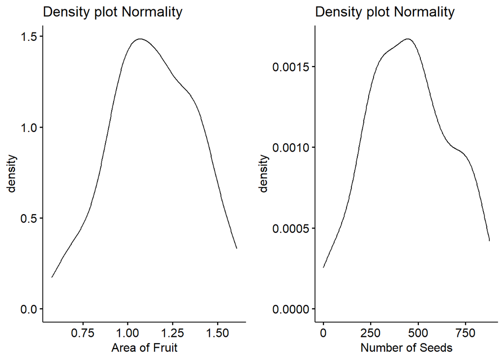

```r
plot_grid(nrow = 1, ncol=2,
          ggdensity(fruits_df$area_fruit, main = "Density plot Normality", xlab = "Area of Fruit"),
          ggdensity(fruits_df$num_seeds, main = "Density plot Normality", xlab = "Number of Seeds"))
```

#### 2.2.2. ANOVA Test for ‘flanks’ variable

We conduct an ANOVA test because the data is parametrical

```r
# Compute the analysis of variance (ANOVA)
flank_aov_area_fruit <- aov(area_fruit ~ Flank, data = fruits_df)
flank_aov_num_seeds <- aov(num_seeds ~ Flank, data = fruits_df)

# Summary of the analysis
summary(flank_aov_area_fruit) # for area of fruit:    p-value = 0.7960    (non-significant)
```

```
##              Df Sum Sq Mean Sq F value Pr(>F)
## Flank         1  0.004 0.00386   0.067  0.796
## Residuals   106  6.063 0.05720
```

```r
summary(flank_aov_num_seeds)  # for number of seeds:  p-value = 0.0258    (significant)
```

```
##              Df  Sum Sq Mean Sq F value Pr(>F)
## Flank         1  221931  221931   5.113 0.0258 *
## Residuals   106 4601332   43409
## ---
## Signif. codes:  0 '***' 0.001 '**' 0.01 '*' 0.05 '.' 0.1 ' ' 1
```

```r
# There is significant difference of number of seeds between one flank and another. On the other hand, there is no significant diference of the area of the fruit between one flank and another ***.
```

#### 2.2.3. Paired Sample T-Test for ‘holes’ variable

We conduct a T-Test because the data is normaly distributed.

```r
t.test(area_fruit ~ Holes, data=fruits_df,
       paired = TRUE, alternative = "two.sided")  # for area of fruit:    p-value = 0.5727   (non-significant)
```

```
##
##  Paired t-test
##
## data:  area_fruit by Holes
## t = 0.56767, df = 53, p-value = 0.5727
## alternative hypothesis: true difference in means is not equal to 0
## 95 percent confidence interval:
##  -0.04287882  0.07673067
## sample estimates:
## mean of the differences
##              0.01692593
```

```r
t.test(num_seeds ~ Holes, data=fruits_df,
       paired = TRUE, alternative = "two.sided")  # for number of fruit:  p-value < 0.001    (significant)
```

```
##
##  Paired t-test
##
## data:  num_seeds by Holes
## t = 4.0468, df = 53, p-value = 0.0001697
## alternative hypothesis: true difference in means is not equal to 0
## 95 percent confidence interval:
##   60.4583 179.2824
## sample estimates:
## mean of the differences
##                119.8704
```

```r
t.test(num_seeds ~ Holes, data=fruits_df,
       paired = TRUE, alternative = "greater")    # for number of fruit:  p-value < 0.001    (significant)
```

```
##
##  Paired t-test
##
## data:  num_seeds by Holes
## t = 4.0468, df = 53, p-value = 8.486e-05
## alternative hypothesis: true difference in means is greater than 0
## 95 percent confidence interval:
##  70.28148      Inf
## sample estimates:
## mean of the differences
##                119.8704
```

#### 2.2.4. ANOVA test for ‘holes’ variable

We can conduct a one-way ANOVA Test test because the data is parametrical

```r
# Compute the analysis of variance (ANOVA)
hole_aov_area_fruit <- aov(area_fruit ~ Holes, data = fruits_df)
hole_aov_num_seeds <- aov(num_seeds ~ Holes, data = fruits_df)

# Summary of the analysis
summary(hole_aov_area_fruit) # for area of fruit:    p-value = 0.7140    (non-significant)
```

```
##              Df Sum Sq Mean Sq F value Pr(>F)
## Holes         1  0.008 0.00774   0.135  0.714
## Residuals   106  6.059 0.05716
```

```r
summary(hole_aov_num_seeds)  # for number of seeds:  p-value = 0.0029    (significant)
```

```
##              Df  Sum Sq Mean Sq F value  Pr(>F)
## Holes         1  387960  387960   9.272 0.00294 **
## Residuals   106 4435302   41842
## ---
## Signif. codes:  0 '***' 0.001 '**' 0.01 '*' 0.05 '.' 0.1 ' ' 1
```

```r
# There is significant difference of number of seeds between pierced / not pierced fruits. On the other hand, there is no significant diference of the area of the fruit between pierced / not pierced fruits ***.
```

#### 2.2.5. ANOVA for interaction ‘flank - holes’ variables for area of fruits

We conduct an ANOVA two-way test test because the data is parametrical:

```r
aov2_area_fruits <- aov(area_fruit ~ Flank * Holes, data = fruits_df)

summary(aov2_area_fruits)
```

```
##              Df Sum Sq Mean Sq F value Pr(>F)
## Flank         1  0.004 0.00386   0.066  0.797
## Holes         1  0.008 0.00774   0.133  0.716
## Flank:Holes   1  0.000 0.00012   0.002  0.963
## Residuals   104  6.055 0.05822
```

```r
# There is NO significant difference of area of fruits between pierced / not pierced fruits, Flanks, neither the interaction of the two factors together ***.
```

#### 2.2.6. ANOVA for interaction ‘flank - holes’ variables for number of seeds

```r
aov2_num_seeds <- aov(num_seeds ~ Flank * Holes, data = fruits_df)

summary(aov2_num_seeds)
```

```
##              Df  Sum Sq Mean Sq F value  Pr(>F)
## Flank         1  221931  221931   5.609 0.01972 *
## Holes         1  387960  387960   9.805 0.00226 **
## Flank:Holes   1   98160   98160   2.481 0.11829
## Residuals   104 4115211   39569
## ---
## Signif. codes:  0 '***' 0.001 '**' 0.01 '*' 0.05 '.' 0.1 ' ' 1
```

```r
# There is significant difference of number of seeds between pierced / not pierced fruits and Flanks. Eventhough there is no significant differences on the interaction of the two factors together, p-value is considerably low (0.1183) ***.
```

#### 2.2.7. Paired Sample T-Test for indirect presence

we cannot conduct a T-Test for indirect presence because the data hasn’t the same sample size.

#### 2.2.8. ANOVA test for indirect presence

We conduct an ANOVA one-way test test because the data is parametrical

```r
# Compute the analysis of variance (ANOVA)
PI_aov_area_fruit <- aov(area_fruit ~ presence_indirect, data = fruits_df)
PI_aov_num_seeds <- aov(num_seeds ~ presence_indirect, data = fruits_df)

# Summary of the analysis
summary(PI_aov_area_fruit) # for area of fruit:    p-value = 0.571    (non-significant)
```

```
##                    Df Sum Sq Mean Sq F value Pr(>F)
## presence_indirect   1  0.018 0.01839   0.322  0.571
## Residuals         106  6.048 0.05706
```

```r
summary(PI_aov_num_seeds)  # for number of seeds:  p-value < 0.001    (significant)
```

```
##                    Df  Sum Sq Mean Sq F value   Pr(>F)
## presence_indirect   1  568296  568296   14.16 0.000276 ***
## Residuals         106 4254967   40141
## ---
## Signif. codes:  0 '***' 0.001 '**' 0.01 '*' 0.05 '.' 0.1 ' ' 1
```

```r
# There is significant difference of number of seeds between pierced / not pierced fruits. On the other hand, there is no significant diference of the area of the fruit between pierced / not pierced fruits ***.
```

#### 2.2.9. ANOVA test for interactions of indirect presence of area of fruits

We conduct an ANOVA two-way test test because the data is parametrical:

```r
PI_aov2_area_fruits <- aov(area_fruit ~ Flank * presence_indirect, data = fruits_df)
summary(PI_aov2_area_fruits)
```

```
##                          Df Sum Sq Mean Sq F value Pr(>F)
## Flank                     1  0.004 0.00386   0.066  0.797
## presence_indirect         1  0.019 0.01930   0.332  0.566
## Flank:presence_indirect   1  0.002 0.00242   0.042  0.839
## Residuals               104  6.041 0.05809
```

```r
# There is NO significant difference of area of fruits between presence / absence of larvae in fruits and Flanks, neither the interaction of the two factors together ***.
```

#### 2.2.10. ANOVA test for interactions of indirect presence of number of seeds

```r
PI_aov2_num_seeds <- aov(num_seeds ~ Flank * presence_indirect, data = fruits_df)

summary(PI_aov2_num_seeds)
```

```
##                          Df  Sum Sq Mean Sq F value   Pr(>F)
## Flank                     1  221931  221931   5.927 0.016614 *
## presence_indirect         1  606114  606114  16.187 0.000109 ***
## Flank:presence_indirect   1  101014  101014   2.698 0.103512
## Residuals               104 3894204   37444
## ---
## Signif. codes:  0 '***' 0.001 '**' 0.01 '*' 0.05 '.' 0.1 ' ' 1
```

```r
# There is significant difference of number of seeds between presence / absence of larvae in fruits and Flanks. Eventhough there is no significant differences on the interaction of the two factors together, p-value is considerably low (0.1035) ***.
```

###### Correlation number of seeds vs. area of fruits

First we create a data.frame with only NOT PIERCED fruits

```r
not_pierced_fruits_df <- fruits_df %>% filter(presence_indirect == "FALSE")

View(not_pierced_fruits_df)

# PI <- Presence Indirect
```

We do a Pearson Correlation test because our data is parametrical (normal distribution). ONLY with not-pierced fruits.

```r
correlation <- cor.test(not_pierced_fruits_df$area_fruit, not_pierced_fruits_df$num_seeds,
                    method = "pearson")

correlation
```

```
##
##  Pearson's product-moment correlation
##
## data:  not_pierced_fruits_df$area_fruit and not_pierced_fruits_df$num_seeds
## t = 6.2687, df = 63, p-value = 3.688e-08
## alternative hypothesis: true correlation is not equal to 0
## 95 percent confidence interval:
##  0.4428372 0.7502759
## sample estimates:
##       cor
## 0.6197939
```

```r
#  p-value< 0.001    (there is significant correlation)
#  Cor. coef. (r) = 0.6198
```

### 2.3. Graphical Representation

#### 2.3.1. Flanks

##### 2.3.1.1. Area of Fruits

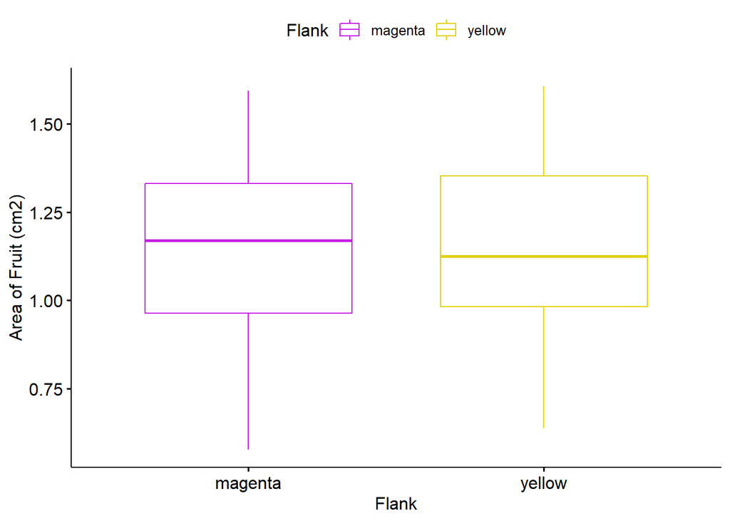

```r
ggboxplot(fruits_df, x = "Flank", y = "area_fruit",
          color = "Flank", palette = c("#C61DE5", "#E2D100"),
          ylab = "Area of Fruit (cm2)", xlab = "Flank")
```

##### 2.3.1.2. Number of Seeds

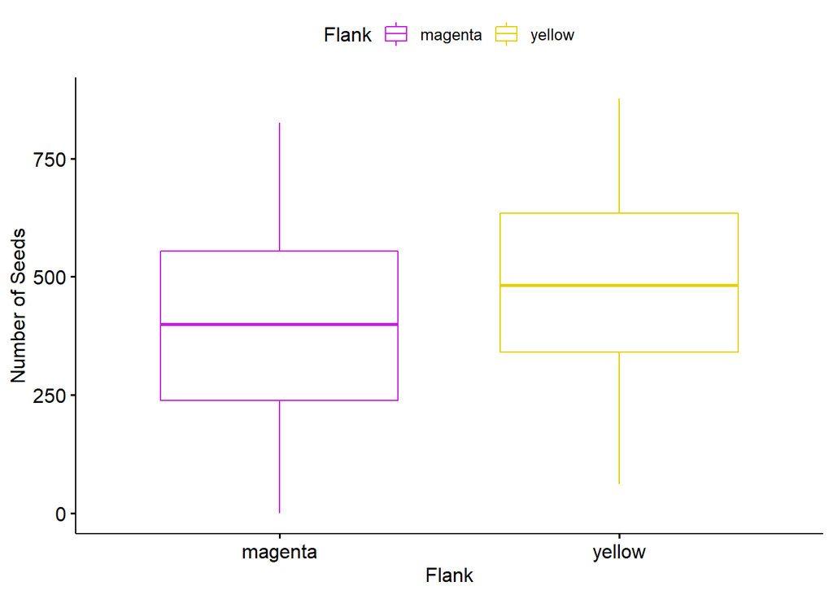

```r
ggboxplot(fruits_df, x = "Flank", y = "num_seeds",
          color = "Flank", palette = c("#C61DE5", "#E2D100"),
          ylab = "Number of Seeds", xlab = "Flank")
```

#### 2.3.2. Holes

##### 2.3.2.1. Area of fruits

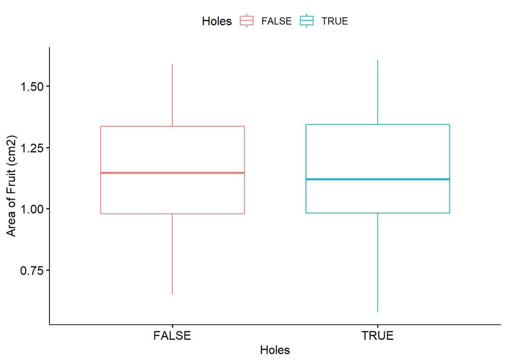

```r
ggboxplot(fruits_df, x = "Holes", y = "area_fruit",
          color = "Holes", ylab = "Area of Fruit (cm2)", xlab = "Holes")
```

##### 2.3.2.2 Number of seeds

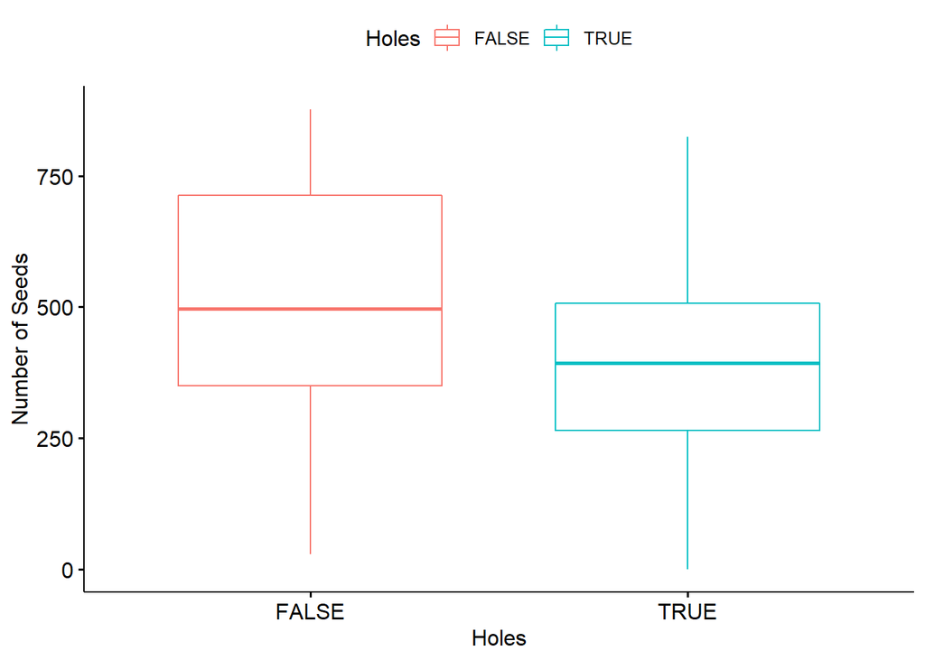

```r
ggboxplot(fruits_df, x = "Holes", y = "num_seeds",
          color = "Holes", ylab = "Number of Seeds", xlab = "Holes")
```

##### 2.3.2.3. Interactions ‘flank - holes’ per area of fruits

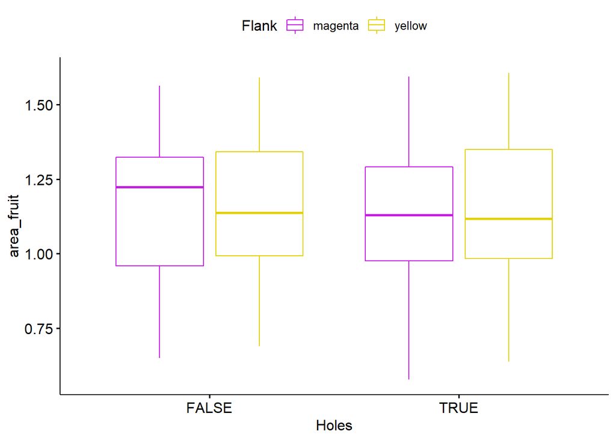

```r
ggboxplot(fruits_df, x = "Holes", y = "area_fruit", color = "Flank",
          palette = c("#C61DE5", "#E2D100"))
```

##### 2.3.2.4. Interactions ‘flank - holes’ per number of seeds

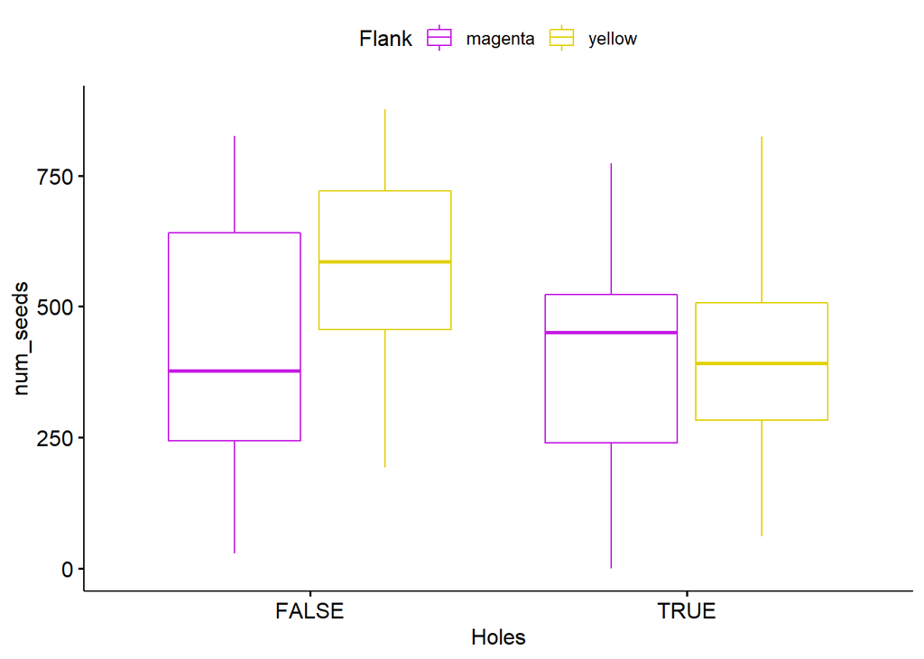

```r
ggboxplot(fruits_df, x = "Holes", y = "num_seeds", color = "Flank",
          palette = c("#C61DE5", "#E2D100"))
```

#### 2.3.3. Indirect presence

##### 2.3.3.1. Area of Fruits

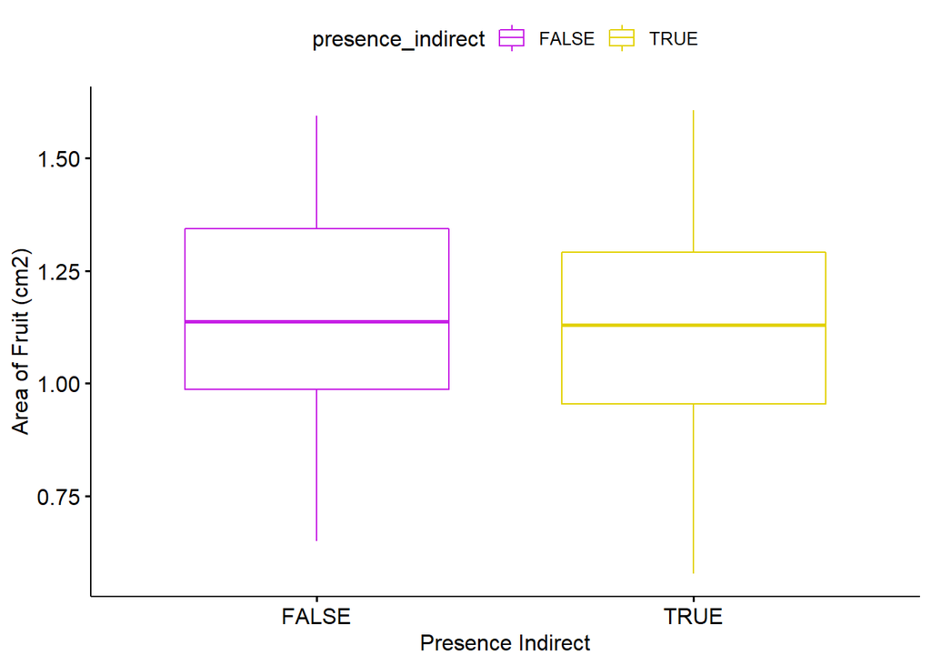

```r
ggboxplot(fruits_df, x = "presence_indirect", y = "area_fruit",
          color = "presence_indirect", palette = c("#C61DE5", "#E2D100"),
          ylab = "Area of Fruit (cm2)", xlab = "Presence Indirect")
```

##### 2.3.3.2. Number of Seeds

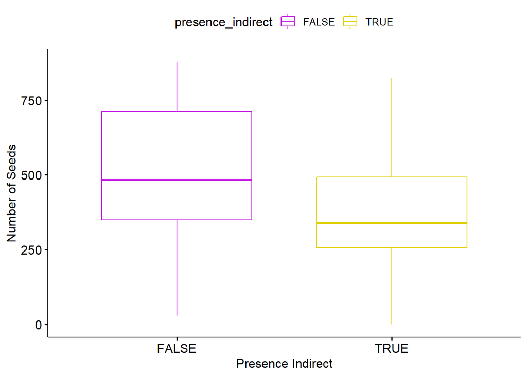

```r
ggboxplot(fruits_df, x = "presence_indirect", y = "num_seeds",
          color = "presence_indirect", palette = c("#C61DE5", "#E2D100"),
          ylab = "Number of Seeds", xlab = "Presence Indirect")
```

##### 2.3.2.4. Interactions ‘flank - indirect presence’ per area of fruit

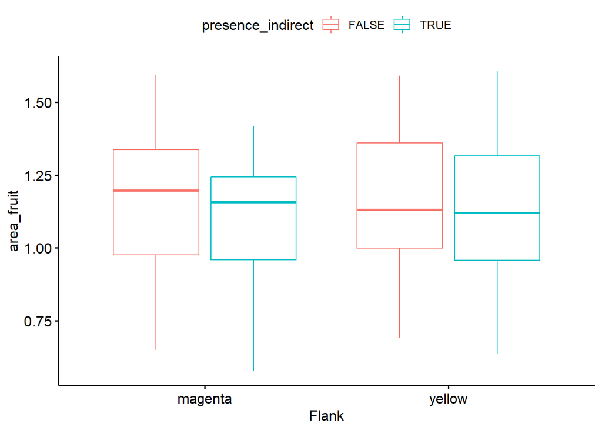

```r
ggboxplot(fruits_df, x = "Flank", y = "area_fruit", color = "presence_indirect")
```

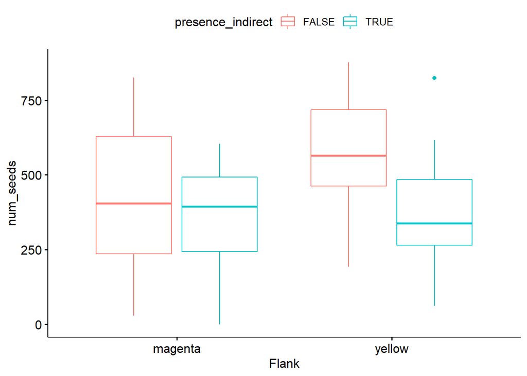

```r
ggboxplot(fruits_df, x = "Flank", y = "num_seeds", color = "presence_indirect")
```

#### 2.3.4. Correlations

##### 2.3.4.1.Number of seeds vs. area of fruit

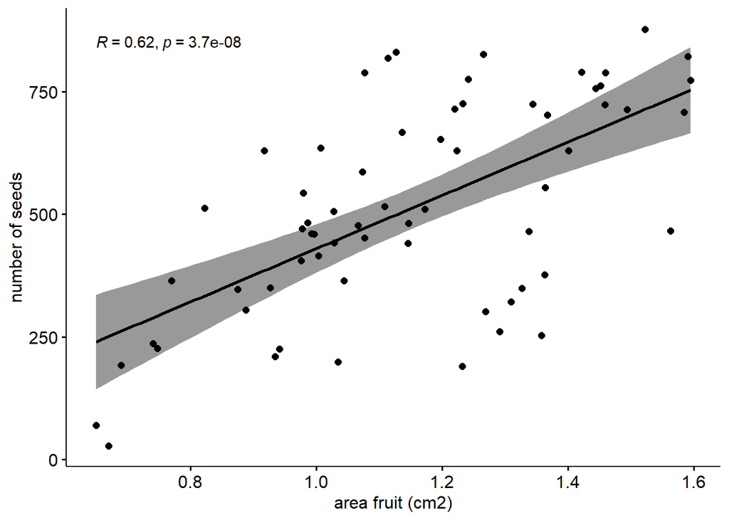

```r
ggscatter(not_pierced_fruits_df, x = "area_fruit", y = "num_seeds",
          add = "reg.line", conf.int = TRUE,
          cor.coef = TRUE, cor.method = "pearson",
          xlab = "area fruit (cm2)", ylab = "number of seeds")
```

Per Flank

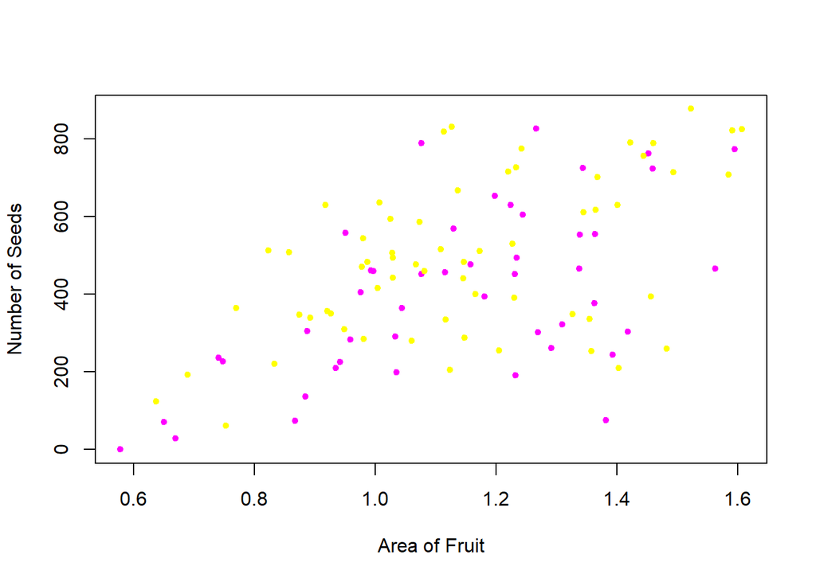

```r
plot(fruits_df$num_seeds ~ fruits_df$area_fruit, col=fruits_df$Flank, ylab="Number of Seeds", xlab="Area of Fruit", pch=20)
```

Per Pierced / not Pierced fruits

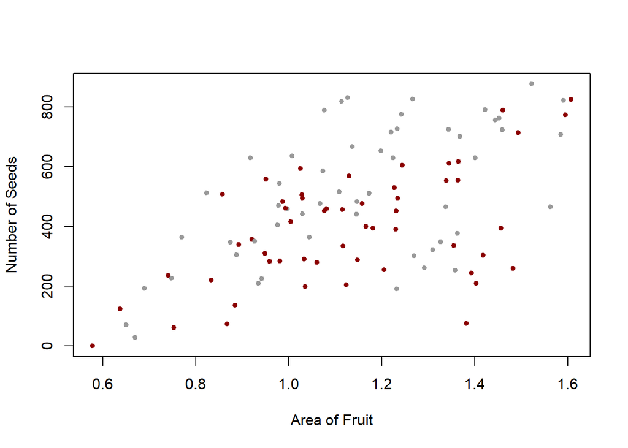

```r
fruits_df$Color <- "grey60"
fruits_df[which(fruits_df$Holes=="TRUE"),]$Color <- "red4"

plot(fruits_df$num_seeds ~ fruits_df$area_fruit, col=fruits_df$Color, ylab="Number of Seeds", xlab="Area of Fruit", pch=20)
```

THINGS TO DO:

- Create a training model for new fruit data
- Take into account frecuency and density of plants